# Continuum theory revisited: what shape are species responses along ecological gradients? - ScienceDirect

## [Ecological Modelling](https://www.sciencedirect.com/science/journal/03043800)

[Volume 157, Issues 2–3](https://www.sciencedirect.com/science/journal/03043800/157/2), 30 November 2002, Pages 119-129

# Continuum theory revisited: what shape are species responses along ecological gradients?

[JariOksanen<sup>a</sup>](https://www.sciencedirect.com/science/article/pii/S0304380002001904#!)[Peter RMinchin<sup>b</sup>](https://www.sciencedirect.com/science/article/pii/S0304380002001904#!)

https://doi.org/10.1016/S0304-3800(02)00190-4[Get rights and content](https://s100.copyright.com/AppDispatchServlet?publisherName=ELS&contentID=S0304380002001904&orderBeanReset=true)

## Abstract

The shape of species’ responses along ecological gradients has important implications for both continuum theory and community analysis. Most current theories and analytical models in community ecology assume that responses are unimodal and symmetric. However, interactions between species and extreme environmental stress may cause skewed or non-unimodal responses. To date, statistical tools for evaluating response shapes have been either inappropriate, inefficient or biased. Using a data set on vascular plant distributions along an elevation gradient, we show that Huisman–Olff–Fresco (HOF) models are an effective method for this purpose, allowing models of various forms (skewed, symmetric, plateau, monotonic) to be tested for adequacy. HOF modeling was compared with alternative methods for response fitting, including Gaussian responses as Generalized linear model (GLMs), Generalized Additive Models (GAM) and Beta Functions with fixed or estimated endpoints. In our data set, skewed and plateau responses are less common than symmetric ones. Less than half of the species have skewed or plateau responses that can not be adequately modeled by Gaussian models. We show that Beta function models with fixed endpoints are biased, confounding skewness and the location of the mode and should not be used to test response shapes. Beta models with estimated endpoints are fairly consistent with other models. GAM's cannot provide clear tests of skewness or kurtosis of response curves, though we show that GAM's, in general, confirmed the shapes chosen by HOF modeling. We provide free software for fitting HOF models and encourage further applications to community data collected along different types of ecological gradients.

## Keywords

Gradient analysis

Beta response function

Gaussian response function

## 1. Introduction

The canonized view in vegetation ecology is that species have symmetric, unimodal responses to ecological gradients (Gauch and Whittaker, 1972, Whittaker, 1978, Begon et al., 1996). At the extreme, this leads into an unrealistic species packing model, where all species are assumed to have Gaussian response functions with identical width and height but with uniformly located optima (Gauch and Whittaker, 1972, ter Braak, 1985). Austin, 1999, Austin, 2002 and many earlier articles, shows clearly that this view is based on very scanty evidence and its canonical status is unfounded. Indeed, theory predicts that response shapes should differ among gradient types (Austin and Smith, 1989) or gradient locations (Austin and Gaywood, 1994). In addition, species interactions may change the response shape even if the fundamental response were symmetric (Austin et al., 1990). Therefore, the analysis of response shape is of great theoretical interest (Austin, 1999). Moreover, it has a practical interest for ecologists because of its implications for ordination methodology. Correspondence analysis (CA) and its derivatives, have been justified using the Gaussian model (ter Braak, 1985), though the validity of justification is open to debate (Austin, 1999, Austin, 2002). The main alternative to CA-based methods, non-metric multidimensional scaling, appears to be robust to variation in response shapes (Minchin, 1987a).

The symmetric Gaussian response function has been the only ecological response model for which the parameters can be estimated effectively (ter Braak and Barendregt, 1986, Jongman et al., 1987). Although the evidence for the Gaussian model can be criticized strongly (Austin, 1976, Austin, 1980, Austin, 1999, Austin, 2002) all the methods proposed so far to test the significance of skewness of the response have been either inadequate, inefficient or biased: visual judgment of skewness (Økland, 1986) is subjective; third-degree polynomials (Austin et al., 1990) have unrealistic shapes; Beta functions (Austin et al., 1994) confound the location of the maximum and the skewness if the response endpoints are fixed (Oksanen, 1997); and the shape of smoothed generalized additive models (GAM) (Hastie and Tibshirani, 1990, Yee and Mitchell, 1991, Bio et al., 1998) must be assessed subjectively. However, Huisman et al. (1993) have proposed a set of hierarchical models which include a skewed response that can be statistically tested against a symmetric response. They assume that these models cannot be estimated using maximum likelihood (Huisman et al., 1993), but we found that this can be done and so it is possible to use more realistic error distribution for the observations than the originally implied normal distribution and to test statistically whether a response is significantly skewed, or whether symmetric or monotonic responses could be used.

In this paper, we study the suitability of Huisman–Olff–Fresco models (HOF) for detecting the shape of species responses along gradients. We compare HOF models against symmetric Gaussian responses, variable Beta responses and non-parametric GAM.

## 2. Material and methods

### 2.1. Data set

We analyzed the response patterns of vascular plants along an altitude gradient on the Mt. Field Plateau, Tasmania, which was earlier used to study the shapes of response surfaces and some other properties of community patterns (Minchin, 1989). Vegetation was sampled with equally spaced sample plots along transects with random starting locations. We stratified the data by soil drainage so that interactions with this second gradient would not distort response shapes. We studied only the well-drained subset in this paper and fitted response models for all species, which occurred on 20 or more sites in this subset. Coverage of sample plots was dense and even in this subset, as is obvious in the graphics in this article. This gave us a data set of 167 sites and 52 species with an altitude range 930–1380 m. We analyzed the data as presence/absence, or binomial with denominator *m*=1.

### 2.2. Bell-shaped or Gaussian response model

The Gaussian model defines a symmetric, bell-shaped response μ along gradient *x* with three interpretable parameters: location of the optimum *u*, height of the response *h* and tolerance or width of the response *t* (Fig. 1):(1)$μ=hexp−(x−u)22t2$

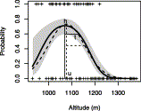

1. [Download : Download full-size image](https://ars.els-cdn.com/content/image/1-s2.0-S0304380002001904-gr1.gif)

Fig. 1. Gaussian response function fitted to *Bauera rubioides*. Continuous lines show a polynomial model with logit link (Eq. (2)) and shading its approximate 95% confidence band. Broken lines show the strict Gaussian model fitted to the same data.

Instead of direct estimation of Gaussian parameters, it is customary to fit an equivalent polynomial model (ter Braak and Looman, 1986):(2)$μ=exp(b0+b1x+b2x2)$

This can be easily fitted as a generalized linear model (GLM) with a logarithmic link function (McCullagh and Nelder, 1989, Guisan et al., 2002) and the maximum likelihood estimates of the Gaussian parameters can be easily found from the polynomial coefficients (ter Braak and Looman, 1986, Oksanen et al., 1988, Oksanen et al., 2001). Quite commonly, the polynomial form is simply called a Gaussian response without explicit reference to the original form (Eq. (1)) and it is even used with link functions other than logarithmic. With other link functions, the general shape of the response is similar to strict Gaussian, but the curve still differs somewhat from the Gaussian and the width parameter (*t*) has a different interpretation for the ecologist (Heegaard, 2002): it no longer gives the gradient distance at which the expected abundance of species drops to a certain fraction of expected maximum *h* (Fig. 1). In this paper, we model the probability of occurrences of species using Binomial *m*=1 error and apply the logistic link function, as is customary with binomial GLM's, instead of the strictly correct logarithmic link.

### 2.3. Beta response model

Austin (1976; Austin et al., 1994) proposed replacing the Gaussian response function with the Beta response function (Fig. 2):(3)$μ=k(x−p1)α(p2−x)γ$

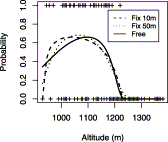

1. [Download : Download full-size image](https://ars.els-cdn.com/content/image/1-s2.0-S0304380002001904-gr2.gif)

Fig. 2. Beta response models fitted to *B. rubioides* with endpoints *p*<sub>1</sub> and *p*<sub>2</sub> fixed either 10 or 50 m beyond the extreme presences and a model where the endpoints were estimated simultaneously with other parameters (the estimates were *p*<sub>1</sub>=−907 and *p*<sub>2</sub>=1239 m, observed range 945–1220 m).

The selection of endpoints has a great effect on fitted response shapes (Fig. 2) and Oksanen (1997) suggested that they should be estimated together with other model parameters, but suspected this to be difficult. However, we found that the simultaneous fitting of all five parameters is relatively simple, but has to be done with non-linear maximum likelihood regression instead of more standard GLM.

Beta response function is unimodal only if *α*>0 and *γ*>0 and so it can define monotone or inverted responses (no optimum, but a minimum). In this article, we interpreted the response shape as monotone if it was strictly monotone within observations. Thus monotone responses include cases where either *α* or *γ* is negative, or where the optimum lies outside the studied range.

### 2.4. Huisman–Olff–Fresco or HOF model

Huisman et al. (1993) proposed a set of five hierarchic models for species response. The most complex model defines a skewed response function and can be written in slightly modified form:(6)$μ=M11+exp(a+bx)11+exp(c−dx)$

Here, *μ* is the expected value, which is dependent on the known values of the gradient (*x*), maximum possible value (*M*) and four estimated parameters of the function (*a*, *b*, *c*, *d*). This model can be simplified into four other models by aliasing some parameters or fixing them to constant values (Table 1). These simplified models define symmetric, plateau type or monotone responses (Fig. 3).

Table 1. Simpler HOF models can be derived from the most complex model V (Eq. (6)) by fixing some parameters to constant values

|  | Model | Parameters |  |  |  |
| --- | --- | --- | --- | --- | --- |
| V | Skewed | *a̱* | *ḇ* | *c̱* | *ḏ* |
| IV | Symmetric | *a̱* | *ḇ* | *c̱* | *b* |
| III | Plateau | *a̱* | *ḇ* | *c̱* | 0 |
| II | Monotone | *a̱* | *ḇ* | 0 | 0 |
| I | Flat | *a̱* | 0 | 0 | 0 |

The estimated parameters are underlined and the fixed parameters in ordinary print.

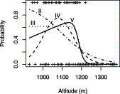

1. [Download : Download full-size image](https://ars.els-cdn.com/content/image/1-s2.0-S0304380002001904-gr3.gif)

Fig. 3. Hierarchic set of HOF models (Table 1) fitted to *B. rubioides*. Model IV was rejected and the estimation continued through model III which was found better than model II.

Huisman et al. (1993) presented only a least-squares method for fitting these models and suggested that maximum likelihood estimation cannot be used. However, the use of maximum likelihood is fairly simple (e.g. Venables and Ripley, 1999). The maximum likelihood estimates can be found by maximizing a log-likelihood function instead of minimizing the squared residuals. The maximum likelihood function used in the HOF model is non-linear in parameters *a*, *b*, *c*, *d* and so these must be estimated using iterative non-linear methods (e.g. Venables and Ripley, 1999).

For statistical testing, the maximized likelihood is transformed into a related statistic known as deviance (Dobson, 1983, McCullagh and Nelder, 1989) which follows asymptotically the *χ*<sup>2</sup> distribution. We study only Binomial *m*=1 models and so we can base our testing directly on the deviance, since overdispersion can occur only in Binomial models where denominator *m*>1 (McCullagh and Nelder, 1989).

The selection of the final model is based on backward elimination, starting with the most complex model (V). The critical level used was *P*=0.05. As the models form a hierarchic series (Table 1), they are simplified in a pre-determined order (McCullagh and Nelder, 1989), V; IV; II and I (Table 1). Model III has the same number of estimated parameters as model IV (Table 1) and therefore, it is omitted from this sequence. However, if model IV is rejected in favor of Model V, the latter is compared against model III and model simplification is continued normally. This introduces a bias against model III, because it may be about as good- or even better-choice than model IV and therefore, we will report results for both models.

### 2.5. Generalized additive models

All previous models had a strict, parametric functional form: we forced them to fit the data. GAM do not specify any strict parametric function, but instead use non-parametric smoothers (Hastie and Tibshirani, 1990). Consequently, they may be able to produce shapes that differ from any parametric model we have studied so far (Fig. 4). GAM's have recently become popular in gradient modeling in vegetation science (e.g. Yee and Mitchell, 1991, Bio et al., 1998, Leathwick, 1998, Heegaard and Hangelbroek, 1999, Ejrnæs, 2000, Lehmann et al., 2002, Zaniewski et al., 2002).

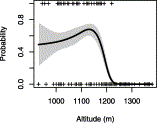

1. [Download : Download full-size image](https://ars.els-cdn.com/content/image/1-s2.0-S0304380002001904-gr4.gif)

Fig. 4. GAM fitted to *B. rubioides* with approximate 95% confidence intervals.

It may be difficult to characterize the shape of response. If a parametric shape is completely within the confidence band of a fitted GAM, the response could be of that parametric shape. In this way, we use GAM to verify or falsify our parametric models and in seeking possible parametric forms.

We use smoothing splines for the predictor. The number of degrees of freedom of the smoother is selected by generalized cross validation (Gu and Wahba, 1991), with upper limit alternatively 3 or 6 degrees of freedom. This was only the upper limit for degrees of freedom: the actual degrees of freedom were found by cross-validation (Wood, 2000, Wood and Augustin, 2002) and were generally much lower. The use of generalized cross-validation is an improvement over the older practice of comparing only some integer alternatives of degrees of freedom.

It may be necessary to trim out extreme sites beyond the species occurrence in multi-gradient models, because GAM fits the model only for the main effects instead of local neighborhood and so zeros outside the main range of the species reduce the fitted values within the main range (Hastie and Tibshirani, 1990). However, we achieved the same by stratifying the data for the secondary gradient (drainage) and so we could use an identical set of sites for all models.

### 2.6. Software

Most statistical analyses were performed using the r software (Ihaka and Gentleman, 1996), which is ‘not unlike s-plus’ (Venables and Ripley, 1999). Most of the analyses are identical in s-plus, but in some cases the algorithms or user commands differ slightly. r is available for free download for several platforms and operating systems at http://cran.r-project.org/.

Gaussian and Beta response functions with fixed endpoints were fitted as GLMs (function glm). GAM are not included in base r, but they are in the recommended library mgcv (function gam). The algorithm used differs somewhat from s-plus (Wood, 2000, Wood and Augustin, 2002).

Maximum likelihood fitting of non-linear HOF models and Beta responses with estimated ‘endpoints’ can be performed with non-linear minimization (function nlm). This is different from s-plus that uses function ms. However, most HOF models were initially fitted using a stand-alone program hof written by Jari Oksanen (JO).

The program hof is available through web pages of JO as compiled binaries for ms-dos/windows and linux. r functions for the analyses and further discussion on analysis methods are available at the same address.

## 3. Results

According to HOF models, symmetric responses were the most common response type (Table 2). These symmetric responses could be adequately fitted using the Gaussian model. About 21% (11 of 52) of responses were skewed which is substantially less than the 33% reported by Minchin (1989). In contrast, Beta functions with fixed endpoints found 37% (19 out of 52) as significantly skewed. However, this was caused by fixing the endpoints before fitting the Beta model, so that skewness and location of optima were confounded (Oksanen, 1997) and Beta functions with freely estimated ‘endpoints’ were more consistent with HOF models (Table 2). Actually, most ‘skewed’ Beta responses with fixed endpoints were very similar to strictly symmetric Gaussian and HOF IV responses and ‘symmetric’ Beta responses fitted the data badly and differed from all alternative models (Fig. 5). Technically ‘skewed’ Beta responses (in the sense that *α*≠*γ*) with fixed endpoints were actually almost symmetric in most cases: instead of producing an asymmetric peak, different *α* and *γ* were used for better fitting of tails, or locating the peak in other places than at the average of the endpoints.

Table 2. The most parsimonous HOF models cross-tabulated against the most parsimonous Beta response models

| HOF model | Total | Beta–estimated endpoints Skewed | Beta–estimated endpoints Symmetric | Beta–estimated endpoints Monotone | Beta–fixed endpoints Skewed | Beta–fixed endpoints Symmetric | Beta–fixed endpoints Monotone |
| --- | --- | --- | --- | --- | --- | --- | --- |
| V | 11 | 9 | 1 | 1 | 7 | 3 | 1 |
| IV | 22 | 4 | 17 | 1 | 12 | 10 |  |
| III | 4 |  | 3 | 1 |  | 4 |  |
| II | 12 | 1 | 2 | 9 |  | 4 | 8 |
| Total | 49 | 14 | 23 | 12 | 19 | 21 | 9 |

The endpoints were fixed 50 m beyond the most extreme presences. One species had an inverted response (no optimum but a minimum) in all models and two species with flat response (model I) were flat or inverted in all other models and these three are not tabulated. The total number of species before these omissions was 52.

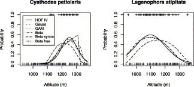

1. [Download : Download full-size image](https://ars.els-cdn.com/content/image/1-s2.0-S0304380002001904-gr5.gif)

Fig. 5. Examples of species which were found to have symmetric bell-shaped responses by HOF models: HOF model IV, Gaussian bell, ‘skewed’ Beta and GAM (df≤3) produced almost similar response, but ‘symmetric’ Beta differs sharply from all others.

All four response models produced very similar responses for species, which were regarded as symmetric, unimodal HOF model IV (Fig. 5). Any of the alternative response models tested seems to be adequate for such species, which are the largest group in our data (Table 2). Similarly, species classified as HOF model II (monotone response) were very similar in all models.

Species classified as skewed responses (HOF model V) or plateau responses (HOF model III) are more interesting. These responses cannot be adequately fitted by Gaussian responses or Beta responses with fixed endpoints and therefore, we compare them against GAM responses and Beta with estimated endpoints. Our comparison was biased in favor of model IV, because we studied model III only if model IV failed. In fact, model III was an alternative parsimonious choice for nine species out of 22 model IV species (Table 2) and for five of these it was indeed a better choice (lower deviance) than model IV. We used this rigorous but discriminatory strategy because we think that a plateau cannot be a global response model, but valid only for a limited range on a gradient.

It seems that GAM models with df≤3 are usually more symmetric than skewed HOF responses (Fig. 6). However, GAM models with df≤6 usually confirm the main peak of the skewed HOF response, but deviate from it in other parts, being usually less regular (Fig. 6). Either the true response is less regular than assumed in parametric modeling, or HOF has a sharper peak than GAM is allowed to have. In general, HOF V models are within confidence limits of GAM's, so that the response looks credible (Fig. 6). Similarly, Beta responses with estimated endpoints were fairly consistent with HOF models (Table 2).

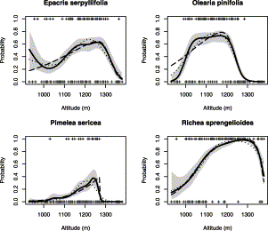

1. [Download : Download full-size image](https://ars.els-cdn.com/content/image/1-s2.0-S0304380002001904-gr6.gif)

Fig. 6. GAM (df≤6) (solid line) with approximate 95% confidence intervals against GAM(df≤3) (dotted line) and HOF V responses (broken line).

Plateau responses (HOF model III) are uncommon and were found only for four species. All these are within the confidence intervals of GAM responses (Fig. 7). GAM responses were not as regular as the simple parametric plateaux of HOF model III. In some cases the GAM response resembles the skewed HOF model V, which was not retained in backwards selection.

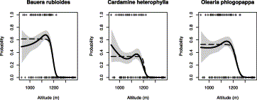

1. [Download : Download full-size image](https://ars.els-cdn.com/content/image/1-s2.0-S0304380002001904-gr7.gif)

Fig. 7. HOF models III responses (broken line) and GAM (df≤3) (solid line) with approximate 95% confidence intervals.

## 4. Discussion

Symmetric, bell-shaped responses were the most common type at Mt. Field and only about one fifth of the responses were clearly skewed. About 42% of species could have been fitted using Gaussian response models. At first sight, these conclusions appear to be in contrast with Minchin (1989) who wrote that “Although the majority of response surfaces appear to be unimodal, only 45% are symmetric”. Actually, despite important differences between two studies (the original paper examined mean cover responses, rather than probabilities of occurrence and fitted two-dimensional response surfaces to both altitude and soil drainage), the observed proportion of symmetric bell responses was similar in both analyses. However, in this paper, we found a larger number of monotone responses (HOF models III, II and I). Minchin (1989) used non-parametric smoothing and had to interpret the shapes subjectively without help of confidence intervals. Obviously his smoothing was not sufficient: in present parlance, he used too many degrees of freedom in fitting. Consequently, he emphasized the irregularity of many responses (regarding 22% of species as having multimodal surfaces), whereas our present analyses did stronger smoothing and found most responses to be fairly regular. Nevertheless, the proportion of non-Gaussian responses is so large that it is hardly possible to say that the Gaussian is the universal and general response type. In particular, one third (11/33) of unimodal responses (models V and IV) are skewed rather than symmetric.

Austin et al. (1994) have proposed strict rules for selecting the species that can be studied for their response shapes. For instance, there should be at least 100 sites with zero observations beyond the extreme presence. Such rules may be applicable to huge data sets at the subcontinental scale, but they are hardly practical for ordinary vegetation surveys. Moreover, even in subcontinental data sets, the rule results in a biased selection of species, leaving out those with modes closer to the gradient extremes. Gradient limits may be natural, like the Mt. Field peak at 1380 m in our case, or they may be arbitrary, like the lower limit of 930 m in our case. Austin's rule does not distinguish between these two cases. The main difference between our approaches is that we are mainly interested in the shape of the species response at the central area of species occurrence, whereas Austin seems more interested in species range and the shapes of the tails. An essential feature of response shape is the slope of decrease near the species optimum and this can be studied even with truncated responses. Contrary to Austin and Nicholls (1997), we think that there is no general need to remove extreme zeros, as most response models are able to predict near-zero occurrence for these. The trimming of zero tails is necessary only for Beta responses with fixed endpoints, since the response is undefined beyond these points (Austin et al., 1994, Austin and Nicholls, 1997, Oksanen, 1997). Trimming of zeros may be necessary in GAM with several gradients, since GAM fit the response for each dimension separately without regarding interactions (Hastie and Tibshirani, 1990). For Gaussian responses, HOF models or Beta models with freely estimated endpoints, there is no need to remove any extreme zeros, since these functions can fit these adequately.

Beta response functions with fixed endpoints failed badly in our analyses. After fixing the response endpoints, or the species range (Austin and Nicholls, 1997), the responses either fitted the data very badly or else failed to detect the appropriate shape because they preferred to find the location of the optimum instead of skewness (Oksanen, 1997). Indeed, Oksanen (1997) suggested that the response endpoints should not be fixed but estimated together with other parameters, so that response curve could try to find both the skewness and the location of the optimum independently and in our case this really improved the applicability of Beta functions.

Fixing the endpoints at the location of the most extreme presences ignores the fact that the data are only a sample. A unimodal response with tapering tails implies that the probability of occurrence near the extremes will be very low. Even with a very large data set, it is, therefore, unlikely that a presence will be observed at the real limit of distribution. Beta response models may be very effective for simulating realistic response patterns along ecological gradients (Minchin, 1987b), but our results show that they are unsuitable for analyzing response shapes, as also concluded by Austin and Meyers (1996).

Any of the studied alternative models could be used for symmetric, bell-shaped responses, even the Beta response model with estimated ‘endpoints’. However, for other response types, Beta functions and Gaussian response models provide biased or inappropriate models. GAM's are usually very similar to the selected HOF models, but smoothness and regularity of shape is dependent on the number of degrees of freedom (Hastie and Tibshirani, 1990). We used generalized cross-validation for selecting the effective smoothness (Gu and Wahba, 1991). Hastie and Tibshirani (1990) found that this fails in several cases and produces responses that are too irregular. Therefore, we defined a fairly low maximum limit for degrees of freedom. However, for detecting skewness, a somewhat higher limit must be used, although this comes at cost of an irregular, perhaps biased pattern in other parts of the response.

We analyzed a real data set and therefore, we cannot know the true underlying response shapes and so we do not know if HOF models actually were correct. However, we compared HOF models against GAM's and symmetric and monotone models against other alternatives and found consistent patterns. In most cases, the final selected HOF model was entirely within the approximate confidence limits of a GAM. The most notable differences were near the extremes of the gradient, where the GAM often flipped up, whereas the corresponding HOF model decreased asymptotically. However, the confidence bands in fitted GAM models increase in the margins as well, so that obviously this is caused by uncertainty at the margins and does not reflect real response shapes. Another inconsistency was in skewed models when compared against strongly smoothed GAM's, but the location and shape of the main peak became consistent with less strong smoothing in GAM, at cost of differences near the gradient margins.

GAM's and HOF models were usually consistent and either could be used in gradient analysis. Recently, GAM's have enjoyed considerable popularity and are seen by some authors as an optimal solution (Yee and Mitchell, 1991, Bio et al., 1998, Leathwick, 1998, Heegaard and Hangelbroek, 1999, Ejrnæs, 2000). The strongest feature of GAM's is that they are indeed non-parametric and can take any smooth shape, whereas even HOF models are restricted to certain shapes. For instance, multimodal responses may be detected with GAM's but are beyond the scope of HOF models. However, the shape of a fitted GAM response must be interpreted subjectively and it may be difficult to say whether a response is really skewed or significantly skewed, or could be just as adequately described in other terms. Shape is, after all, a parametric concept: if we say that a response is skewed, the only difference compared with a symmetric response should be the skewness. GAM's may be a good choice for general predictive modeling of species responses, but for parametric questions of shape, parametric HOF models appear to provide a better alternative.

Many more studies of response patterns along ecological gradients are needed to provide a sound observational basis for continuum theory. HOF models provide an effective tool for studying the shapes of species’ responses and we hope that the availability of software for HOF modeling will encourage the reexamination of existing data sets and stimulate further investigations into the nature of community patterns.

## Acknowledgements

We wish to thank Dr Mike Austin and Dr Alain Zuur for invaluable comments on the manuscript.

## References

**Austin, 1976**

M.P Austin

**On non-linear species responses models in ordination**

Vegetatio, 33 (1976), pp. 33-41

[View Record in Scopus](https://www.scopus.com/inward/record.url?eid=2-s2.0-0002932496&partnerID=10&rel=R3.0.0)[Google Scholar](https://scholar.google.com/scholar_lookup?title=On%20non-linear%20species%20responses%20models%20in%20ordination&publication_year=1976&author=M.P%20Austin)

**Austin, 1980**

M.P Austin

**Searching for a model for use in vegetation analysis**

Vegetatio, 42 (1980), pp. 11-21

[View Record in Scopus](https://www.scopus.com/inward/record.url?eid=2-s2.0-0002209765&partnerID=10&rel=R3.0.0)[Google Scholar](https://scholar.google.com/scholar_lookup?title=Searching%20for%20a%20model%20for%20use%20in%20vegetation%20analysis&publication_year=1980&author=M.P%20Austin)

**Austin, 1999**

M.P Austin

**On silent clash of paradigms: some inconsistencies in community ecology**

Oikos, 86 (1999), pp. 170-178

[CrossRef](https://doi.org/10.2307/3546582)[View Record in Scopus](https://www.scopus.com/inward/record.url?eid=2-s2.0-0033057694&partnerID=10&rel=R3.0.0)[Google Scholar](https://scholar.google.com/scholar_lookup?title=On%20silent%20clash%20of%20paradigms%3A%20some%20inconsistencies%20in%20community%20ecology&publication_year=1999&author=M.P%20Austin)

**Austin, 2002**

M.P Austin

**Spatial prediction of species distribution: an interface between ecological theory and statistical modelling**

Ecol. Model., 157 (2–3) (2002), pp. 101-118

[Article](https://www.sciencedirect.com/science/article/pii/S0304380002002053)[Download PDF](https://www.sciencedirect.com/science/article/pii/S0304380002002053/pdfft?md5=86e234d10027be96b145a234b47113f6&pid=1-s2.0-S0304380002002053-main.pdf)[View Record in Scopus](https://www.scopus.com/inward/record.url?eid=2-s2.0-0037202447&partnerID=10&rel=R3.0.0)Google Scholar

**Austin and Smith, 1989**

M.P Austin, T.M Smith

**A new model for the continuum concept**

Vegetatio, 83 (1989), pp. 35-47

[View Record in Scopus](https://www.scopus.com/inward/record.url?eid=2-s2.0-0024928332&partnerID=10&rel=R3.0.0)[Google Scholar](https://scholar.google.com/scholar_lookup?title=A%20new%20model%20for%20the%20continuum%20concept&publication_year=1989&author=M.P%20Austin&author=T.M%20Smith)

**Austin and Gaywood, 1994**

M.P Austin, M.J Gaywood

**Current problems of environmental gradients and species response curves in relation to continuum theory**

J. Veg. Sci., 5 (1994), pp. 473-482

[CrossRef](https://doi.org/10.2307/3235973)[View Record in Scopus](https://www.scopus.com/inward/record.url?eid=2-s2.0-0028565621&partnerID=10&rel=R3.0.0)Google Scholar

**Austin and Meyers, 1996**

M.P Austin, J.A Meyers

**Current approaches to modelling the environmnetal niche of eucalypts: implications for management of forest biodiversity**

Forest Ecol. Manage., 85 (1996), pp. 95-106

[Article](https://www.sciencedirect.com/science/article/pii/S037811279603753X)[Download PDF](https://www.sciencedirect.com/science/article/pii/S037811279603753X/pdf?md5=2de813be1c85e8b88a6aeed6d7e72151&pid=1-s2.0-S037811279603753X-main.pdf)[View Record in Scopus](https://www.scopus.com/inward/record.url?eid=2-s2.0-0030236493&partnerID=10&rel=R3.0.0)Google Scholar

**Austin and Nicholls, 1997**

M.P Austin, A.O Nicholls

**To fix or not to fix the species limits, that is the ecological question: response to Jari Oksanen**

J. Veg. Sci., 8 (1997), pp. 743-748

[CrossRef](https://doi.org/10.2307/3237380)[View Record in Scopus](https://www.scopus.com/inward/record.url?eid=2-s2.0-0031459041&partnerID=10&rel=R3.0.0)Google Scholar

**Austin et al., 1990**

M.P Austin, A.O Nicholls, C.R Margules

**Measurement of the realized qualitative niche: environmental niches of five *Eucalyptus* species**

Ecol. Monogr., 60 (1990), pp. 161-177

[CrossRef](https://doi.org/10.2307/1943043)[View Record in Scopus](https://www.scopus.com/inward/record.url?eid=2-s2.0-0025250844&partnerID=10&rel=R3.0.0)Google Scholar

**Austin et al., 1994**

M.P Austin, A.O Nicholls, M.D Doherty, J.A Meyers

**Determining species response functions to an environmental gradient by means of a β-function**

J. Veg. Sci., 5 (1994), pp. 215-228

[CrossRef](https://doi.org/10.2307/3236154)[View Record in Scopus](https://www.scopus.com/inward/record.url?eid=2-s2.0-0028174803&partnerID=10&rel=R3.0.0)[Google Scholar](https://scholar.google.com/scholar?q=Determining%20species%20response%20functions%20to%20an%20environmental%20gradient%20by%20means%20of%20a%20-function)

**Begon et al., 1996**

M Begon, J.L Harper, C.R Townsend

Ecology: Individuals, Populations and Communities (third ed.), Blackwell (1996)

[Google Scholar](https://scholar.google.com/scholar_lookup?title=Ecology%3A%20Individuals%2C%20Populations%20and%20Communities&publication_year=1996&author=M%20Begon&author=J.L%20Harper&author=C.R%20Townsend)

**Bio et al., 1998**

A.M.F Bio, R Alkemade, A Barendregt

**Determining alternative models for vegetation response analysis: a non-parametric approach**

J. Veg. Sci., 9 (1998), pp. 5-16

[CrossRef](https://doi.org/10.2307/3237218)[View Record in Scopus](https://www.scopus.com/inward/record.url?eid=2-s2.0-0003043818&partnerID=10&rel=R3.0.0)Google Scholar

**Dobson, 1983**

A.J Dobson

An Introduction to Statistical Modelling, Chapman and Hall (1983)

[Google Scholar](https://scholar.google.com/scholar_lookup?title=An%20Introduction%20to%20Statistical%20Modelling&publication_year=1983&author=A.J%20Dobson)

**Ejrnæs, 2000**

R Ejrnæs

**Can we trust gradients extracted by detrended correspondence analysis**

J. Veg. Sci., 11 (2000), pp. 565-572

[CrossRef](https://doi.org/10.2307/3246586)[View Record in Scopus](https://www.scopus.com/inward/record.url?eid=2-s2.0-0033786588&partnerID=10&rel=R3.0.0)[Google Scholar](https://scholar.google.com/scholar_lookup?title=Can%20we%20trust%20gradients%20extracted%20by%20detrended%20correspondence%20analysis&publication_year=2000&author=R%20Ejrn%C3%A6s)

**Gauch and Whittaker, 1972**

H.G Gauch Jr, R.H Whittaker

**Coenocline simulation**

Ecology, 53 (1972), pp. 446-451

[CrossRef](https://doi.org/10.2307/1934231)[View Record in Scopus](https://www.scopus.com/inward/record.url?eid=2-s2.0-0000754195&partnerID=10&rel=R3.0.0)[Google Scholar](https://scholar.google.com/scholar_lookup?title=Coenocline%20simulation&publication_year=1972&author=H.G%20Gauch%20Jr&author=R.H%20Whittaker)

**Gu and Wahba, 1991**

C Gu, G Wahba

**Minimizing GCV/GML scores with multiple smoothing parameters via the Newton method**

SIAM J. Sci. Stat. Comp., 12 (1991), pp. 383-398

[CrossRef](https://doi.org/10.1137/0912021)[View Record in Scopus](https://www.scopus.com/inward/record.url?eid=2-s2.0-0001003992&partnerID=10&rel=R3.0.0)[Google Scholar](https://scholar.google.com/scholar?q=Minimizing%20GCVGML%20scores%20with%20multiple%20smoothing%20parameters%20via%20the%20Newton%20method)

**Guisan et al., 2002**

A Guisan, T.C Edwards, T Hastie

**Generalized linear and generalized additive models in studies of species distributions: setting the scene**

Ecol. Model., 157 (2–3) (2002), pp. 89-100

[Article](https://www.sciencedirect.com/science/article/pii/S0304380002002041)[Download PDF](https://www.sciencedirect.com/science/article/pii/S0304380002002041/pdfft?md5=dd86d365641a68f266202802c18d8165&pid=1-s2.0-S0304380002002041-main.pdf)[View Record in Scopus](https://www.scopus.com/inward/record.url?eid=2-s2.0-0037202446&partnerID=10&rel=R3.0.0)Google Scholar

**Hastie and Tibshirani, 1990**

T.J Hastie, R.J Tibshirani

Generalized Additive Models, Chapman and Hall, London (1990), p. 92

[Google Scholar](https://scholar.google.com/scholar_lookup?title=Generalized%20Additive%20Models&publication_year=1990&author=T.J%20Hastie&author=R.J%20Tibshirani)

**Heegaard, 2002**

E Heegaard

**The outer border and central border for species environmental relationships estimated by non-parametric generalized additive models**

Ecol. Model., 157 (2–3) (2002), pp. 131-139

[Article](https://www.sciencedirect.com/science/article/pii/S0304380002001916)[Download PDF](https://www.sciencedirect.com/science/article/pii/S0304380002001916/pdfft?md5=21606b05be2649eab99ee49802f2ee4b&pid=1-s2.0-S0304380002001916-main.pdf)[View Record in Scopus](https://www.scopus.com/inward/record.url?eid=2-s2.0-0037202449&partnerID=10&rel=R3.0.0)Google Scholar

**Heegaard and Hangelbroek, 1999**

E Heegaard, H.H Hangelbroek

**The distribution of *Ulota crispa* in relation to both dispersal- and habitat-related factors**

Lindbergia, 24 (1999), pp. 65-74

[View Record in Scopus](https://www.scopus.com/inward/record.url?eid=2-s2.0-0032757050&partnerID=10&rel=R3.0.0)Google Scholar

**Huisman et al., 1993**

J Huisman, H Olff, L.F.M Fresco

**A hierarchical set of models for species response analysis**

J. Veg. Sci., 4 (1993), pp. 37-46

[CrossRef](https://doi.org/10.2307/3235732)[View Record in Scopus](https://www.scopus.com/inward/record.url?eid=2-s2.0-0027427088&partnerID=10&rel=R3.0.0)[Google Scholar](https://scholar.google.com/scholar_lookup?title=A%20hierarchical%20set%20of%20models%20for%20species%20response%20analysis&publication_year=1993&author=J%20Huisman&author=H%20Olff&author=L.F.M%20Fresco)

**Ihaka and Gentleman, 1996**

R Ihaka, R Gentleman

**r: a language for data analysis and graphics**

J. Comput. Graph. Stat., 5 (1996), pp. 299-314

[View Record in Scopus](https://www.scopus.com/inward/record.url?eid=2-s2.0-0030305457&partnerID=10&rel=R3.0.0)[Google Scholar](https://scholar.google.com/scholar_lookup?title=r%3A%20a%20language%20for%20data%20analysis%20and%20graphics&publication_year=1996&author=R%20Ihaka&author=R%20Gentleman)

**Jongman et al., 1987**

Jongman, R.H., ter Braak, C.J.F., van Tongeren, O.F.R., 1987. Data analysis in community and landscape ecology, Pudoc, Wageningen.

[Google Scholar](https://scholar.google.com/scholar?q=Jongman,%20R.H.,%20ter%20Braak,%20C.J.F.,%20van%20Tongeren,%20O.F.R.,%201987.%20Data%20analysis%20in%20community%20and%20landscape%20ecology,%20Pudoc,%20Wageningen.)

**Kay and Little, 1987**

R Kay, S Little

**Transformations of the explanatory variables in the logistic regression model for binary data**

Biometrika, 74 (1987), pp. 495-501

[View Record in Scopus](https://www.scopus.com/inward/record.url?eid=2-s2.0-0000496222&partnerID=10&rel=R3.0.0)Google Scholar

**Leathwick, 1998**

J.R Leathwick

**Are New Zealand's *Nothofagus* species in equilibrium with their environment**

J. Veg. Sci., 9 (1998), pp. 719-732

[CrossRef](https://doi.org/10.2307/3237290)[View Record in Scopus](https://www.scopus.com/inward/record.url?eid=2-s2.0-0032451492&partnerID=10&rel=R3.0.0)[Google Scholar](https://scholar.google.com/scholar?q=Are%20New%20Zealands%20Nothofagus%20species%20in%20equilibrium%20with%20their%20environment)

**Lehmann et al., 2002**

A Lehmann, J.M Overton, J.R Leathwick

**Generalized regression analysis and apatial predictions**

Ecol. Model., 157 (2–3) (2002), pp. 187-205

[CrossRef](https://doi.org/10.1038/sj.dmfr.4600682)[View Record in Scopus](https://www.scopus.com/inward/record.url?eid=2-s2.0-0036525729&partnerID=10&rel=R3.0.0)[Google Scholar](https://scholar.google.com/scholar_lookup?title=Generalized%20regression%20analysis%20and%20apatial%20predictions&publication_year=2002&author=A%20Lehmann&author=J.M%20Overton&author=J.R%20Leathwick)

**McCullagh and Nelder, 1989**

P McCullagh, J.A Nelder

Generalized Linear Models, Chapman and Hall, London (1989), p. 125

[View Record in Scopus](https://www.scopus.com/inward/record.url?eid=2-s2.0-0011645938&partnerID=10&rel=R3.0.0)[Google Scholar](https://scholar.google.com/scholar_lookup?title=Generalized%20Linear%20Models&publication_year=1989&author=P%20McCullagh&author=J.A%20Nelder)

**Minchin, 1987a**

P.R Minchin

**An evaluation of relative robustness of techniques for ecological ordinations**

Vegetatio, 69 (1987), pp. 89-107

[CrossRef](https://doi.org/10.1007/978-94-009-4061-1_9)[View Record in Scopus](https://www.scopus.com/inward/record.url?eid=2-s2.0-0023519385&partnerID=10&rel=R3.0.0)[Google Scholar](https://scholar.google.com/scholar_lookup?title=An%20evaluation%20of%20relative%20robustness%20of%20techniques%20for%20ecological%20ordinations&publication_year=1987&author=P.R%20Minchin)

**Minchin, 1987b**

P.R Minchin

**Simulation of multidimensional community patterns: towards a comprehensive model**

Vegetatio, 71 (1987), pp. 145-156

[View Record in Scopus](https://www.scopus.com/inward/record.url?eid=2-s2.0-0023501643&partnerID=10&rel=R3.0.0)[Google Scholar](https://scholar.google.com/scholar_lookup?title=Simulation%20of%20multidimensional%20community%20patterns%3A%20towards%20a%20comprehensive%20model&publication_year=1987&author=P.R%20Minchin)

**Minchin, 1989**

P.R Minchin

**Montane vegetation of the Mt. Field massif, Tasmania: a test of some hypotheses about properties of community patterns**

Vegetatio, 83 (1989), pp. 97-110

[View Record in Scopus](https://www.scopus.com/inward/record.url?eid=2-s2.0-0024885539&partnerID=10&rel=R3.0.0)Google Scholar

**Økland, 1986**

R.H Økland

**Rescaling of ecological gradients. The effect of scale on symmetry of species response curves**

Nordic J. Bot., 6 (1986), pp. 671-677

[View Record in Scopus](https://www.scopus.com/inward/record.url?eid=2-s2.0-84981569502&partnerID=10&rel=R3.0.0)Google Scholar

**Oksanen, 1997**

J Oksanen

**Why the beta-function cannot be used to estimate skewness of species responses**

J. Veg. Sci., 8 (1997), pp. 147-152

[CrossRef](https://doi.org/10.2307/3237252)[View Record in Scopus](https://www.scopus.com/inward/record.url?eid=2-s2.0-0030942569&partnerID=10&rel=R3.0.0)[Google Scholar](https://scholar.google.com/scholar_lookup?title=Why%20the%20beta-function%20cannot%20be%20used%20to%20estimate%20skewness%20of%20species%20responses&publication_year=1997&author=J%20Oksanen)

**Oksanen et al., 1988**

J Oksanen, E Läärä, P Huttunen, J Meriläinen

**Estimation of pH optima and tolerances of diatoms in lake sediments by the methods of weighted averaging, least-squares and maximum likelihood, and their use for the prediction of lake acidity**

J. Paleolimnol., 1 (1988), pp. 39-49

[View Record in Scopus](https://www.scopus.com/inward/record.url?eid=2-s2.0-0024258572&partnerID=10&rel=R3.0.0)Google Scholar

**Oksanen et al., 2001**

J Oksanen, E Läärä, J Meriläinen, B.G Warner

**Confidence intervals for the optimum in the Gaussian response function**

Ecology, 82 (2001), pp. 1191-1197

[View Record in Scopus](https://www.scopus.com/inward/record.url?eid=2-s2.0-0035063942&partnerID=10&rel=R3.0.0)Google Scholar

**ter Braak, 1985**

C.J.F ter Braak

**Correspondence analysis of incidence and abundance data: properties in terms of a unimodal response model**

Biometrics, 41 (1985), pp. 859-873

[CrossRef](https://doi.org/10.2307/2530959)Google Scholar

**ter Braak and Barendregt, 1986**

C.J.F ter Braak, L.G Barendregt

**Weighted averaging of species indicator values: its efficiency in environmental calibration**

Math. Biosci., 78 (1986), pp. 57-72

[Article](https://www.sciencedirect.com/science/article/pii/0025556486900313)[Download PDF](https://www.sciencedirect.com/science/article/pii/0025556486900313/pdf?md5=e92a776870144bd129766c49e441f2a3&pid=1-s2.0-0025556486900313-main.pdf)[View Record in Scopus](https://www.scopus.com/inward/record.url?eid=2-s2.0-0022613514&partnerID=10&rel=R3.0.0)Google Scholar

**ter Braak and Looman, 1986**

C.J.F ter Braak, C.W.N Looman

**Weighted averaging, logistic regression and the Gaussian response model**

Vegetatio, 65 (1986), pp. 3-11

[View Record in Scopus](https://www.scopus.com/inward/record.url?eid=2-s2.0-0022903880&partnerID=10&rel=R3.0.0)[Google Scholar](https://scholar.google.com/scholar_lookup?title=Weighted%20averaging%2C%20logistic%20regression%20and%20the%20Gaussian%20response%20model&publication_year=1986&author=C.J.F%20ter%20Braak&author=C.W.N%20Looman)

**Venables and Ripley, 1999**

W.M Venables, B.D Ripley

Modern Applied Statistics with s-plus (third ed.), Springer, Heidelberg (1999)

[Google Scholar](https://scholar.google.com/scholar_lookup?title=Modern%20Applied%20Statistics%20with%20s-plus&publication_year=1999&author=W.M%20Venables&author=B.D%20Ripley)

**Whittaker, 1978**

R.H Whittaker

**Direct gradient analysis**

R.H Whittaker (Ed.), Ordination of Plant Communities, Junk, The Hague (1978), pp. 7-50

[CrossRef](https://doi.org/10.1007/978-94-009-7989-5_2)[Google Scholar](https://scholar.google.com/scholar_lookup?title=Direct%20gradient%20analysis&publication_year=1978&author=R.H%20Whittaker)

**Wood, 2000**

S.N Wood

**Modelling and smoothing parameter estimation with multiple quadratic penalties**

J. Roy. Stat. Soc., B62 (2000), pp. 413-428

[View Record in Scopus](https://www.scopus.com/inward/record.url?eid=2-s2.0-0034364945&partnerID=10&rel=R3.0.0)[Google Scholar](https://scholar.google.com/scholar_lookup?title=Modelling%20and%20smoothing%20parameter%20estimation%20with%20multiple%20quadratic%20penalties&publication_year=2000&author=S.N%20Wood)

**Wood and Augustin, 2002**

Wood, S.N., Augustin, N.H., 2002. Improving GAMs for environmental modelling using GCV and penalized regression splines. Ecol. Mod., This Volume, in this issue.

Google Scholar

**Yee and Mitchell, 1991**

T.W Yee, N.D Mitchell

**Generalized additive models in plant ecology**

J. Veg. Sci., 2 (1991), pp. 587-602

[CrossRef](https://doi.org/10.2307/3236170)[View Record in Scopus](https://www.scopus.com/inward/record.url?eid=2-s2.0-84986799949&partnerID=10&rel=R3.0.0)[Google Scholar](https://scholar.google.com/scholar_lookup?title=Generalized%20additive%20models%20in%20plant%20ecology&publication_year=1991&author=T.W%20Yee&author=N.D%20Mitchell)

**Zaniewski et al., 2002**

A.E Zaniewski, A Lehmann, J.M Overton

**Predicting species distribution using presence-only data: A case study of native New Zealand ferns**

Ecol. Model., 157 (2–3) (2002), pp. 259-278

Google Scholar

[View Abstract](https://www.sciencedirect.com/science/article/abs/pii/S0304380002001904)

Copyright © 2002 Elsevier Science B.V. All rights reserved.